# Linking community science data with population dynamics under stochastic process in the context of ecological release

Orlando Acevedo-Charry & José Miguel Ponciano

2023-12-10

## Could eBird data track population dynamics in time-series in the context of ecological release?

Ecological release: Population level niche expansion and/or shift when antagonistic interspecific interaction is removed or reduced (Herrmann *et al.*, *TREE* 2021). Hypothetical ecological release could be explored as a function of species richness. Lower competition in islands expand niche (*e.g.*, abundance), while more habitats and more species increase level of specialization in the Mainland (Sherry *et al.*, *Auk* 2020).

To test a model of stochasticity process, we selected a widespread and easy to detect species in the meta-archipelago, which are distributed from the Mainland to different islands in the Caribbean: Bananaquit *Coereba flaveola*. Theory predicts that species in the mainland have lower density than islands, and that density could increase as species richness and potentially interspecific competition decreases.

The packages

```r
#####   Filtering Caribbean Archipelago birds   ####

####~Packages~####
library(auk); #eBird data filters
library(tidyverse); #manipulate data
library(elevatr);
library(dclone);
```

```
##
##
## dclone 2.3-2      2023-07-02
```

```r
library(MASS);
```

```r
library(mcmcplots)
```

The code in HiperGator was:

```r
####################
####~ eBird data ~####
####################

#Data downloaded from eBird, up to December 2022

#reference to an ebd in preparatio for filtering using awk auk_ebd("ebd_relDec-2022.txt")

##I create a path to a new polygon with to save my filter ()
f_ebd <- "ebd_Carib_OAC.txt"                         #Data to be saved
f_sed <- "sed_Carib_OAC.txt"                         #Sampling event to be saved

#select the columns to extract (based on x$col_idx$name)
colsE <- c("observer_id", "sampling_event_identifier",
                "group identifier",
                "common_name", "scientific_name",
                "observation_count",
                "state_code", "locality_id", "latitude", "longitude",
                "protocol_type", "all_species_reported",
                "observation_date",
                "time_observations_started",
                "duration_minutes", "effort_distance_km",
                "number_observers")

#Filtering the data
ebd_filt<-auk_ebd("ebd_relAug-2023.txt",
                  file_sampling = "ebd_sampling_relAug-2023.txt") %>%
  auk_bbox(c(-91, 8, -59, 27)) %>% #W, S, E, N - the Caribbean basin
  auk_year(c(2012:2023)) %>%
  auk_protocol(c("Traveling", "Stationary")) %>%
  auk_distance(distance = c(0,2)) %>%
  auk_duration(duration = c(0,120))%>%
  auk_complete() %>%
  auk_filter(f_ebd, f_sed, overwrite=T, keep = colsE)

#and with read_ebd I apply another filter to do not repeate records from groups
sed_only <- read_sampling(f_sed)
ebd_only <- read_ebd(f_ebd)

#effort and more filtering (May, Julian days 125-150)

# Function to convert time observation to hours since midnight
time_to_decimal <- function(x) {
  x <- hms(x, quiet = TRUE)
  hour(x) + minute(x) / 60 + second(x) / 3600
}

ebd_eff <- ebd_only %>%
    mutate(
    # I don't have here count in X to convert to NA
        observation_count = as.integer(observation_count),
    # effort_distance_km to 0 for non-travelling counts
        effort_distance_km = if_else(protocol_type == "Stationary",
                                 0, effort_distance_km),
    # convert time to decimal hours since midnight
        time_observations_started = time_to_decimal(time_observations_started),
        hour_sampling = round(time_observations_started, 0),
    # split date into year, month, week, and day of year
        year = year(observation_date),
        month = month(observation_date),
        week = week(observation_date),
        day_of_year = yday(observation_date)) %>%
    filter(number_observers <= 10,  #Only list with less than 10 observers
           effort_distance_km <= 2,           #be sure of distance effort
           duration_minutes %in% (10:120),           #be sure of duration effort
           day_of_year %in% (125:150),
           hour_sampling %in% (6:11))        #only the days of May

write.csv(ebd_eff, "ebd_Filtered_Caribbean_relAug_2023.csv")

##Sampling file (zero-fill)

sed_eff <- sed_only %>%
    mutate(
    # effort_distance_km to 0 for non-travelling counts
        effort_distance_km = if_else(protocol_type == "Stationary",
                                 0, effort_distance_km),
    # convert time to decimal hours since midnight
        time_observations_started = time_to_decimal(time_observations_started),
        hour_sampling = round(time_observations_started, 0),
    # split date into year, month, week, and day of year
        year = year(observation_date),
        month = month(observation_date),
        week = week(observation_date),
        day_of_year = yday(observation_date)) %>%
    filter(number_observers <= 10,  #Only list with less than 10 observers
           effort_distance_km <= 2,           #be sure of distance effort
           duration_minutes %in% (10:120),           #be sure of duration effort
         day_of_year %in% (125:150),
           hour_sampling %in% (6:11))        #only the days of May

write.csv(sed_eff, "ebd_sedFiltered_Caribbean_relAug_2023.csv")
```

With these data (ebd: 159MB), we can extract the species and further assess other covariates, like the primary lifestyle (Tobias *et al.*, *Ecol. Lett.* 2022), or the elevation.

Let’s filter by the elevation of each record, so we exclude those species recorded in open ocean.

```r
ebd_eff <- read.csv("ebd_Filtered_Caribbean_relAug_2023.csv")

#Get elevation
crs_dd = 4326 #WGS84 and EPSG:4326 are the crs to use latitude and longitude coordinates

examp_sf <- sf::st_as_sf(ebd_eff[,c(8:9)], coords = c("longitude", "latitude"), crs = crs_dd)

#get elevation by point using Amazon Web Service Terrain Tails, with zoom 15 that gives ~150km resolution
ebd_elev <- get_elev_point(examp_sf, prj = crs_dd, src = "aws", z = 8)
```

```
## Mosaicing & Projecting
```

```
## Note: Elevation units are in meters
```

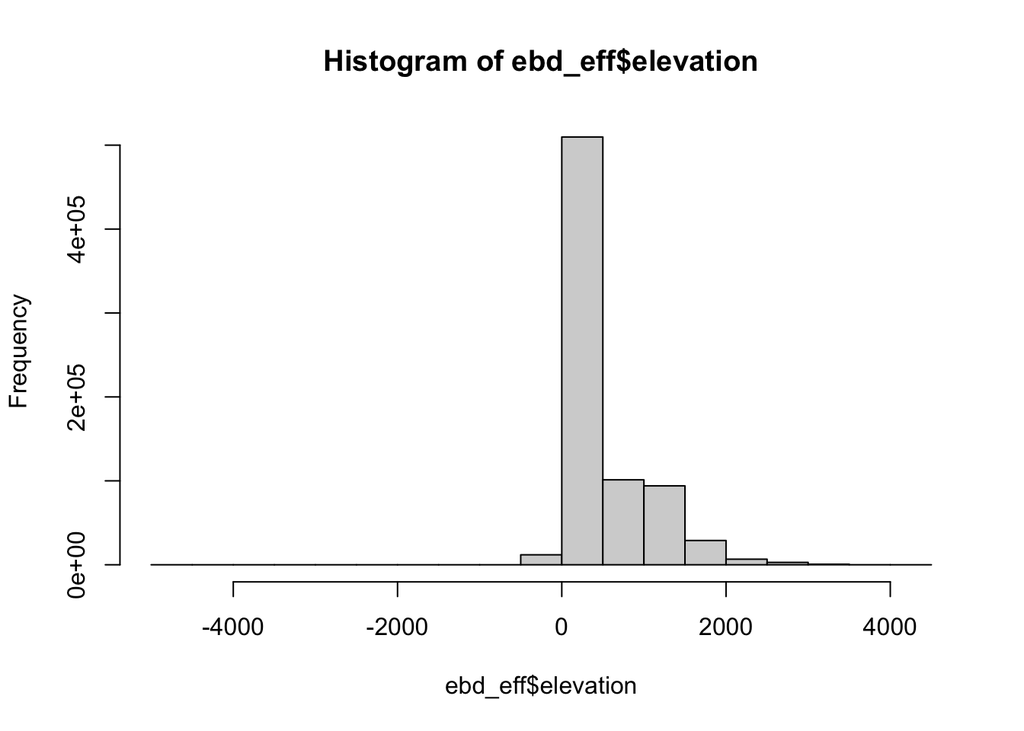

```r
#Combine again with the original dataset

ebd_eff$elevation <- ebd_elev$elevation

hist(ebd_eff$elevation)
```

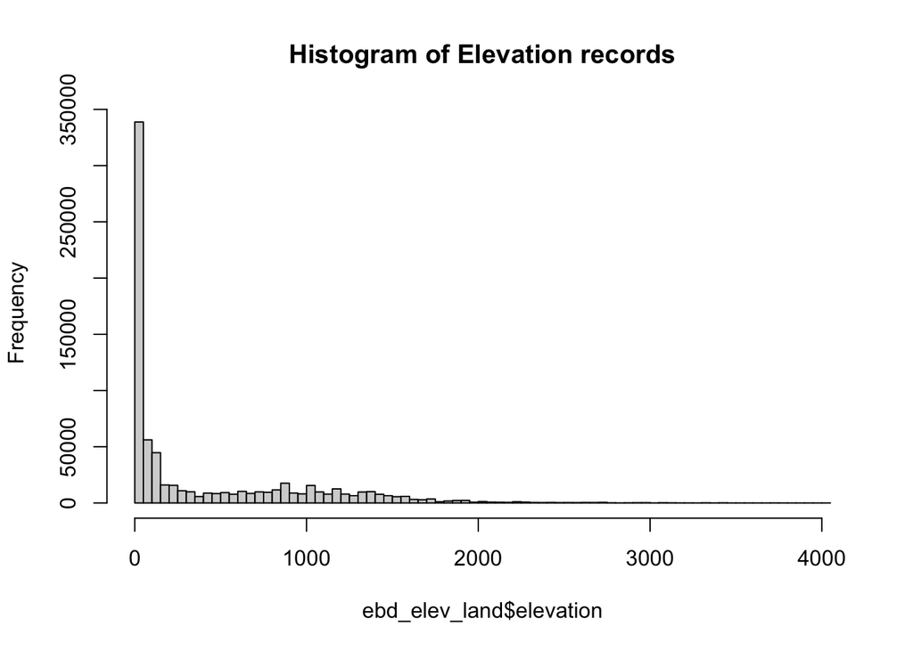

```r
#And filter out those "marine" records (elevation ≥ 0)
ebd_elev_land <- ebd_eff %>%
  filter(elevation >=0);
hist(ebd_elev_land$elevation, breaks = 100, main = "Histogram of Elevation records")
```

Now, let’s combine the functional traits (mean value) from AVONET (Tobias *et al.*, *Ecol. Lett.* 2022), and exclude aquatic birds and those without enough data (12 years of counts).

```r
avonet <- read.csv("AVONET_eBird.csv")
table(avonet$Primary.Lifestyle)
```

```
##
##      Aerial     Aquatic  Generalist Insessorial Terrestrial
##         827         276         951        6286        2321
```

```r
#Let's remove aquatic birds
carib <- avonet %>%
  filter(Primary.Lifestyle != "Aquatic")

#Filter those species recorded in eBird that have data in AVONET (excluding aquatic)
ebird.carib = ebd_elev_land[ebd_elev_land$scientific_name %in% carib$Species2, ]

#to combine the data, we have to adjust the names

names(carib)[2] <- "scientific_name"

carib.ebird <- left_join(ebird.carib, carib, by = "scientific_name") %>% #combine datasets
  as.data.frame()

spp <- carib.ebird %>%
  dplyr::select(scientific_name, year, observation_count) %>%
  group_by(scientific_name, year) %>%
  summarise(n_counts = mean(observation_count, na.rm = T),
            sd_counts = sd(observation_count, na.rm = T),
            n_checklists = n()) %>%
  filter(n_checklists >=5) %>%
  group_by(scientific_name) %>%
  summarise(YearsCount = n(), mu_counts = mean(n_counts)) %>%
  filter(YearsCount > 11)
spp.carib <- left_join(spp, carib.ebird, by = "scientific_name")

spp.carib %>%
  group_by(state_code,scientific_name) %>%
  summarise(records = n()) %>%
  count(state_code, sort = T)
```

```
## # A tibble: 360 × 2
## # Groups:   state_code [360]
##    state_code     n
##    <chr>      <int>
##  1 CR-G         162
##  2 CR-P         161
##  3 BZ-BZ        149
##  4 CR-A         149
##  5 HN-CR        148
##  6 MX-ROO       146
##  7 BZ-SC        144
##  8 HN-AT        140
##  9 MX-YUC       139
## 10 CR-C         138
## # ℹ 350 more rows
```

Now, let’s play with our species of interest, the Bananaquit *Coereba flaveola*

```r
Coefla <- spp.carib %>%
  dplyr::filter(scientific_name == "Coereba flaveola")

#Which states?
Coefla %>%
  group_by(state_code) %>%
  count(sort = T)
```

```
## # A tibble: 255 × 2
## # Groups:   state_code [255]
##    state_code     n
##    <chr>      <int>
##  1 VE-M         521
##  2 CR-P         287
##  3 CR-A         249
##  4 AW-          229
##  5 VE-I         181
##  6 TT-TUP       148
##  7 PA-4         147
##  8 GP-          144
##  9 CR-C         142
## 10 CR-H         134
## # ℹ 245 more rows
```

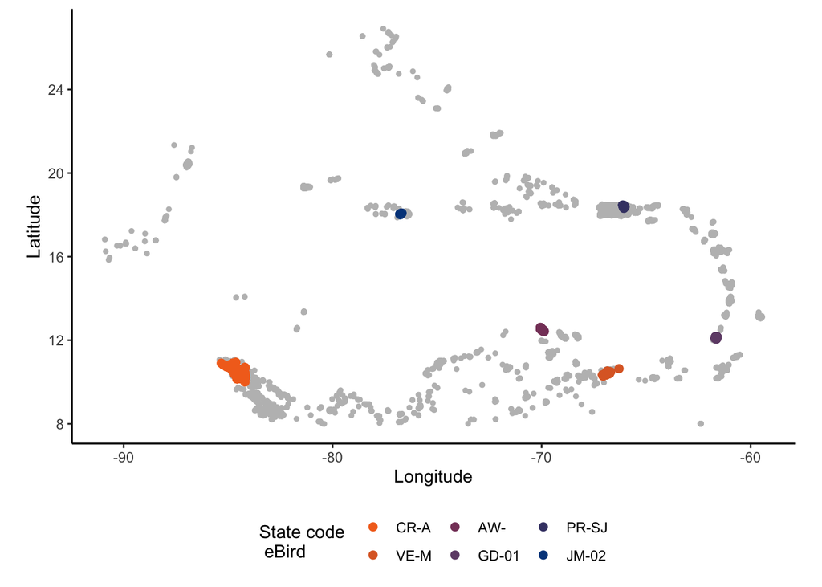

```r
#We will selected 6 populations of more than 15 records to estimate differences of abundance across spp richness reported in eBird:
  #CR-P (161), VE-M (76), AW- (67), PR-SJ (51), GD-01 (39), JM-02 (31)

Coefla$Pop <- ifelse(Coefla$state_code %in% c("CR-A", "VE-M", "AW-", "PR-SJ", "GD-01", "JM-02"),yes = 1, no = 0)

Selected <- Coefla %>% filter(Pop == 1)
NoSelected <- Coefla %>% filter(Pop == 0)

#where this data came from?
ggplot()+
  geom_point(data = NoSelected, aes(x = longitude, y = latitude), color = "gray", size = 1)+
  geom_point(data = Selected, aes(x = longitude, y = latitude, color = state_code), size = 2)+
  scale_color_manual(values = c("#F36F20", "#DD692E", "#864268", "#704C76", "#434174","#01458A"),
                     limits = c("CR-A", "VE-M", "AW-", "GD-01", "PR-SJ", "JM-02"))+
  theme_classic()+
  labs(x = "Longitude", y = "Latitude", color = "State code \n eBird")+
  coord_fixed()+
  theme(legend.position = "bottom")
```

We assumed that the mean $\mu_{t,s}$ of counts each year $t$ in each site $s$ represents the stationary distribution of the stochastic density dependence in the population.

```r
Pop <- Selected %>%
  group_by(state_code, year) %>%
  summarise(mu_count = mean(observation_count, na.rm = T),
            sd_count = sd(observation_count, na.rm = T),
            n_records = n())
```

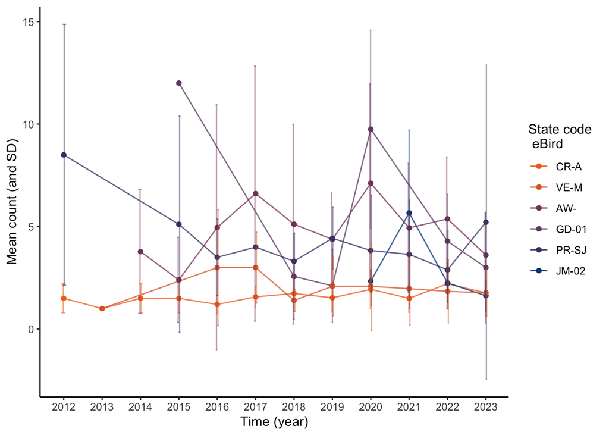

```r
ggplot(Pop, aes(x = year, y = mu_count, color = state_code))+
  geom_line(alpha = 0.75)+
  geom_point()+
  geom_errorbar(aes(ymin=mu_count-sd_count, ymax=mu_count+sd_count), width=.2,
                 position=position_dodge(0.05), alpha = 0.5)+
  scale_color_manual(values = c("#F36F20", "#DD692E", "#864268", "#704C76", "#434174","#01458A"),
                     limits = c("CR-A", "VE-M", "AW-", "GD-01", "PR-SJ", "JM-02"))+
  scale_x_continuous(breaks = seq(2012,2023,1))+
  theme_classic()+
  labs(x = "Time (year)", y = "Mean count (and SD)", color = "State code \n eBird")+
  theme(legend.position = "right")
```

Lele *et al.* (*Ecol. Lett.* 2007) provide the example of the GSS model as a stochastic, density-dependent model (based on Dennis *et al.*, *Ecol. Monogr.* 2006). In this model, the latent variable of $N_t$ as the true abundance at time $t$ in the form:
$$N_t = N_{t-1}* {\rm exp} \left(a + b * {\rm ln}N_{t-1} + E_t \right)$$
where $a$ is the intrinsic growth rate (a constant) and $b$ is a density dependence parameter (another constant), while the environmental stochasticity is $E_t \sim {\rm Normal}(0,\sigma^2)$. The variance $\sigma^2$ is the process noise or environmental variability of the system (Lele *et al.*, *Ecol. Lett.* 2007), where higher values could serve to identify catastrophic stochasticity (Dennis *et al.*, *Ecol. Monogr.* 1991).

Thus, we can define $X_t = {\rm ln}(N_t)$, or the logarithm of the unobserved population abundances at time $t$, $t=(0,1,...,q)$. Applying the logarithm scale:

$$X_t = X_{t-1} + a + (b*X_{t-1}) + E_t$$
factorizing out,
$$X_t = a + X_{t-1}(1+b) + E_t$$
and simplify the terms, $c=1+b$ defines the density dependence parameter:

$$X_t = a + cX_{t-1} + E_t$$

Let’s use the Poisson process (adjust to the length of the time series). Here is the GSS.dc model:

```r
StochGSS2.dc <- function(){

  # Priors on model parameters. Priors are DC1 in Lele et al (2007)
    a1 ~ dnorm(0,1);   # constant, the population growth rate.
    c1 ~ dunif(-1,1);      # constant, the density dependence parameter.
    sig1 ~ dlnorm(-0.5,10); #variance parameter of stochastic  environment (process noise) in the system
    stovar1 <- 1/pow(sig1,2)

    for(k in 1:K){
      # Simulate trajectory that depends on the previous
      mean_X1[1,k] <- a1/(1-c1) # Expected value of the first realization of the process
                          # this is drawn from the stationary distribution of the process
                          # Equation 14 (main text) and  A.4 in Appendix of Dennis et al 2006
      Varno1[k] <- pow(sig1,2)/(1-pow(c1,2)) #. Equation A.5 in Appendix of Dennis et al 2006


      # Updating the state: Stochastic process for 29 steps
      X1[1,k]~dnorm(mean_X1[1,k], 1/Varno1[k]); #first estimation of population

      #iteration of the GSS model in the data
      for (i in 2:12) {
        mean_X1[i,k] <- a1 + c1 * X1[(i - 1),k]
        X1[i,k] ~ dnorm(mean_X1[i,k], stovar1) # Et is included here since a+cX(t-1) + Et ~ Normal(a+cX(t-1),sigma^2)
      }

    # Updating the observations, from the counts
      for (i in 1:12) {
        Y1[i,k] ~ dpois(exp(X1[i,k])) #Here we can plug the probability of detection, p*exp(X1[i,k]), and we could also estimate it from the data!
      }
  }

}
```

Now, we select the data, first Costa Rica - Alejuela (CR-A), which has complete data 2012-2023.

```r
table(Pop$state_code, Pop$year)
```

```
##
##         2012 2013 2014 2015 2016 2017 2018 2019 2020 2021 2022 2023
##   AW-      0    0    1    1    1    1    1    1    1    1    1    1
##   CR-A     1    1    1    1    1    1    1    1    1    1    1    1
##   GD-01    0    0    0    1    0    0    1    1    1    0    1    1
##   JM-02    0    0    0    0    0    0    0    0    1    1    1    1
##   PR-SJ    1    0    0    1    1    1    1    1    1    1    1    1
##   VE-M     0    1    0    0    1    1    1    1    1    1    1    1
```

```r
#Costa Rica - Alejuela

CR.A <- Pop %>%
  dplyr::filter(state_code == "CR-A") %>%
  dplyr::select(mu_count)
CR <- round(CR.A$mu_count, 0)

datalistGSS.CR.dc <- list(K = 1,
                       Y1 = dcdim(data.matrix(CR))) # Not need to be in LOG!!!

dcrun.GSS2.CR <- dc.fit(data = datalistGSS.CR.dc,
                          params = c("a1", "c1", "sig1"), #extract from the model
                          model = StochGSS2.dc,
                          n.clones = c(5,10,50,100,150),
                          multiply = "K",
                          n.chains = 10,
                          n.adapt = 1000,
                          n.update = 1000,
                          thin = 10,
                          n.iter = 10000)
```

```
##
## Fitting model with 5 clones
```

```
##
##
##
## Fitting model with 10 clones
##
##
##
##
## Fitting model with 50 clones
##
##
##
##
## Fitting model with 100 clones
##
##
##
##
## Fitting model with 150 clones
##
##
```

```r
summary(dcrun.GSS2.CR);
```

```
##
## Iterations = 2010:12000
## Thinning interval = 10
## Number of chains = 10
## Sample size per chain = 1000
## Number of clones = 150
##
## 1. Empirical mean and standard deviation for each variable,
##    plus standard error of the mean:
##
##          Mean      SD  DC SD  Naive SE Time-series SE R hat
## a1    0.63634 0.13225 1.6198 0.0013225      0.0142399 2.164
## c1   -0.05640 0.21534 2.6373 0.0021534      0.0252033 2.155
## sig1  0.07905 0.01169 0.1431 0.0001169      0.0006469 1.024
##
## 2. Quantiles for each variable:
##
##         2.5%      25%      50%     75%  97.5%
## a1    0.4106  0.53141  0.62678 0.73978 0.8921
## c1   -0.4616 -0.22369 -0.03980 0.11802 0.3148
## sig1  0.0576  0.07076  0.07874 0.08673 0.1032
```

```r
dcdiag(dcrun.GSS2.CR)
```

```
##   n.clones lambda.max    ms.error   r.squared    r.hat
## 1        5 0.12173528 0.147280842 0.018087615 1.008351
## 2       10 0.09217436 0.092491547 0.012654891 1.018067
## 3       50 0.06561554 0.166250316 0.022233957 1.270372
## 4      100 0.04536919 0.007735087 0.001265776 1.376825
## 5      150 0.06361632 0.044086658 0.006011624 2.215608
```

Now, Aruba (Lesser Antilles), missing the two first years of data, complete data 2014-2023

```r
A <- Pop %>%
  dplyr::filter(state_code == "AW-") %>%
  dplyr::select(mu_count)
```

```r
AW <- c(round(A$mu_count, 0)) #the

#and have to adjust the model
StochGSS2.AW.dc <- function(){

  # Priors on model parameters. Priors are DC1 in Lele et al (2007)
    a1 ~ dnorm(0,1);   # constant, the population growth rate.
    c1 ~ dunif(-1,1);      # constant, the density dependence parameter.
    sig1 ~ dlnorm(-0.5,10); #variance parameter of stochastic  environment (process noise) in the system
    stovar1 <- 1/pow(sig1,2)

    for(k in 1:K){
      # Simulate trajectory that depends on the previous
      mean_X1[1,k] <- a1/(1-c1) # Expected value of the first realization of the process
                          # this is drawn from the stationary distribution of the process
                          # Equation 14 (main text) and  A.4 in Appendix of Dennis et al 2006
      Varno1[k] <- pow(sig1,2)/(1-pow(c1,2)) #. Equation A.5 in Appendix of Dennis et al 2006


      # Updating the state: Stochastic process for 29 steps
      X1[1,k]~dnorm(mean_X1[1,k], 1/Varno1[k]); #first estimation of population

      #iteration of the GSS model in the data
      for (i in 2:10) {
        mean_X1[i,k] <- a1 + c1 * X1[(i - 1),k]
        X1[i,k] ~ dnorm(mean_X1[i,k], stovar1) # Et is included here since a+cX(t-1) + Et ~ Normal(a+cX(t-1),sigma^2)
      }

    # Updating the observations, from the counts
      for (i in 1:10) {
        Y1[i,k] ~ dpois(exp(X1[i,k])) #Here we can plug the probability of detection, p*exp(X1[i,k]), and we could also estimate it from the data!
      }
  }

}


datalistGSS.AW.dc <- list(K = 1,
                       Y1 = dcdim(data.matrix(AW))) # Not need to be in LOG!!!

dcrun.GSS2.AW <- dc.fit(data = datalistGSS.AW.dc,
                          params = c("a1", "c1", "sig1"), #extract from the model
                          model = StochGSS2.AW.dc,
                          n.clones = c(5,10,50,100,150),
                          multiply = "K",
                          n.chains = 10,
                          n.adapt = 1000,
                          n.update = 1000,
                          thin = 10,
                          n.iter = 10000)
```

```
##
## Fitting model with 5 clones
##
##
##
##
## Fitting model with 10 clones
##
##
##
##
## Fitting model with 50 clones
##
##
##
##
## Fitting model with 100 clones
##
##
##
##
## Fitting model with 150 clones
##
##
```

```r
summary(dcrun.GSS2.AW);
```

```
##
## Iterations = 2010:12000
## Thinning interval = 10
## Number of chains = 10
## Sample size per chain = 1000
## Number of clones = 150
##
## 1. Empirical mean and standard deviation for each variable,
##    plus standard error of the mean:
##
##         Mean      SD  DC SD  Naive SE Time-series SE R hat
## a1   1.47779 0.16549 2.0268 0.0016549      0.0164617 3.411
## c1   0.05636 0.10559 1.2932 0.0010559      0.0114513 3.409
## sig1 0.07058 0.01003 0.1229 0.0001003      0.0004785 1.029
##
## 2. Quantiles for each variable:
##
##          2.5%      25%     50%     75%   97.5%
## a1    1.17565  1.36450 1.48257 1.61294 1.75146
## c1   -0.12005 -0.03069 0.05209 0.12844 0.24965
## sig1  0.05184  0.06361 0.07021 0.07722 0.09143
```

```r
dcdiag(dcrun.GSS2.AW)
```

```
##   n.clones lambda.max    ms.error    r.squared    r.hat
## 1        5 0.23692465 0.109272911 0.0103427908 1.044076
## 2       10 0.21031614 0.032025536 0.0043161132 1.143095
## 3       50 0.08361797 0.061931127 0.0073695602 1.638979
## 4      100 0.04579585 0.005593897 0.0005981074 2.829589
## 5      150 0.03849957 0.045319525 0.0020800820 3.463621
```

```r
PR.SJ <- Pop %>%
  dplyr::filter(state_code == "PR-SJ") %>%
  dplyr::select(mu_count)
```

```r
PR <- c(round(PR.SJ$mu_count, 0)) #the

#and have to adjust the model
StochGSS2.PR.dc <- function(){

  # Priors on model parameters. Priors are DC1 in Lele et al (2007)
    a1 ~ dnorm(0,1);   # constant, the population growth rate.
    c1 ~ dunif(-1,1);      # constant, the density dependence parameter.
    sig1 ~ dlnorm(-0.5,10); #variance parameter of stochastic  environment (process noise) in the system
    stovar1 <- 1/pow(sig1,2)

    for(k in 1:K){
      # Simulate trajectory that depends on the previous
      mean_X1[1,k] <- a1/(1-c1) # Expected value of the first realization of the process
                          # this is drawn from the stationary distribution of the process
                          # Equation 14 (main text) and  A.4 in Appendix of Dennis et al 2006
      Varno1[k] <- pow(sig1,2)/(1-pow(c1,2)) #. Equation A.5 in Appendix of Dennis et al 2006


      # Updating the state: Stochastic process for 29 steps
      X1[1,k]~dnorm(mean_X1[1,k], 1/Varno1[k]); #first estimation of population

      #iteration of the GSS model in the data
      for (i in 2:10) {
        mean_X1[i,k] <- a1 + c1 * X1[(i - 1),k]
        X1[i,k] ~ dnorm(mean_X1[i,k], stovar1) # Et is included here since a+cX(t-1) + Et ~ Normal(a+cX(t-1),sigma^2)
      }

    # Updating the observations, from the counts
      for (i in 1:10) {
        Y1[i,k] ~ dpois(exp(X1[i,k])) #Here we can plug the probability of detection, p*exp(X1[i,k]), and we could also estimate it from the data!
      }
  }

}


datalistGSS.PR.dc <- list(K = 1,
                       Y1 = dcdim(data.matrix(PR))) # Not need to be in LOG!!!

dcrun.GSS2.PR <- dc.fit(data = datalistGSS.PR.dc,
                          params = c("a1", "c1", "sig1"), #extract from the model
                          model = StochGSS2.PR.dc,
                          n.clones = c(5,10,50,100,150),
                          multiply = "K",
                          n.chains = 10,
                          n.adapt = 1000,
                          n.update = 1000,
                          thin = 10,
                          n.iter = 10000)
```

```
##
## Fitting model with 5 clones
##
##
##
##
## Fitting model with 10 clones
##
##
##
##
## Fitting model with 50 clones
##
##
##
##
## Fitting model with 100 clones
##
##
##
##
## Fitting model with 150 clones
##
##
```

```r
summary(dcrun.GSS2.PR);
```

```
##
## Iterations = 2010:12000
## Thinning interval = 10
## Number of chains = 10
## Sample size per chain = 1000
## Number of clones = 150
##
## 1. Empirical mean and standard deviation for each variable,
##    plus standard error of the mean:
##
##         Mean      SD  DC SD  Naive SE Time-series SE R hat
## a1   1.40797 0.12608 1.5442 0.0012608      0.0146512 2.386
## c1   0.04783 0.08559 1.0483 0.0008559      0.0109575 2.400
## sig1 0.07430 0.01055 0.1292 0.0001055      0.0004948 1.057
##
## 2. Quantiles for each variable:
##
##          2.5%       25%     50%     75%   97.5%
## a1    1.17365  1.321415 1.41011 1.48967 1.64247
## c1   -0.11219 -0.006851 0.04662 0.10823 0.20695
## sig1  0.05419  0.067085 0.07407 0.08136 0.09533
```

```r
dcdiag(dcrun.GSS2.PR)
```

```
##   n.clones lambda.max    ms.error   r.squared    r.hat
## 1        5 0.23667771 0.187716034 0.020211243 1.044026
## 2       10 0.16433215 0.249410852 0.028115575 1.071722
## 3       50 0.13778217 0.039521782 0.006486024 2.289090
## 4      100 0.05385060 0.030919907 0.003342418 2.002165
## 5      150 0.02317616 0.009621974 0.001518602 2.439791
```

```r
VE.M <- Pop %>%
  dplyr::filter(state_code == "VE-M") %>%
  dplyr::select(mu_count)
```

```r
VE <- c(round(VE.M$mu_count, 0)) #the

#and have to adjust the model
StochGSS2.VE.dc <- function(){

  # Priors on model parameters. Priors are DC1 in Lele et al (2007)
    a1 ~ dnorm(0,1);   # constant, the population growth rate.
    c1 ~ dunif(-1,1);      # constant, the density dependence parameter.
    sig1 ~ dlnorm(-0.5,10); #variance parameter of stochastic  environment (process noise) in the system
    stovar1 <- 1/pow(sig1,2)

    for(k in 1:K){
      # Simulate trajectory that depends on the previous
      mean_X1[1,k] <- a1/(1-c1) # Expected value of the first realization of the process
                          # this is drawn from the stationary distribution of the process
                          # Equation 14 (main text) and  A.4 in Appendix of Dennis et al 2006
      Varno1[k] <- pow(sig1,2)/(1-pow(c1,2)) #. Equation A.5 in Appendix of Dennis et al 2006


      # Updating the state: Stochastic process for 29 steps
      X1[1,k]~dnorm(mean_X1[1,k], 1/Varno1[k]); #first estimation of population

      #iteration of the GSS model in the data
      for (i in 2:9) {
        mean_X1[i,k] <- a1 + c1 * X1[(i - 1),k]
        X1[i,k] ~ dnorm(mean_X1[i,k], stovar1) # Et is included here since a+cX(t-1) + Et ~ Normal(a+cX(t-1),sigma^2)
      }

    # Updating the observations, from the counts
      for (i in 1:9) {
        Y1[i,k] ~ dpois(exp(X1[i,k])) #Here we can plug the probability of detection, p*exp(X1[i,k]), and we could also estimate it from the data!
      }
  }

}


datalistGSS.VE.dc <- list(K = 1,
                       Y1 = dcdim(data.matrix(VE))) # Not need to be in LOG!!!

dcrun.GSS2.VE <- dc.fit(data = datalistGSS.VE.dc,
                          params = c("a1", "c1", "sig1"), #extract from the model
                          model = StochGSS2.VE.dc,
                          n.clones = c(5,10,50,100,150),
                          multiply = "K",
                          n.chains = 10,
                          n.adapt = 1000,
                          n.update = 1000,
                          thin = 10,
                          n.iter = 10000)
```

```
##
## Fitting model with 5 clones
##
##
##
##
## Fitting model with 10 clones
##
##
##
##
## Fitting model with 50 clones
##
##
##
##
## Fitting model with 100 clones
##
##
##
##
## Fitting model with 150 clones
##
##
```

```r
summary(dcrun.GSS2.VE);
```

```
##
## Iterations = 2010:12000
## Thinning interval = 10
## Number of chains = 10
## Sample size per chain = 1000
## Number of clones = 150
##
## 1. Empirical mean and standard deviation for each variable,
##    plus standard error of the mean:
##
##          Mean      SD  DC SD  Naive SE Time-series SE R hat
## a1    0.76033 0.12286 1.5048 0.0012286      0.0153641 1.723
## c1   -0.10467 0.17493 2.1424 0.0017493      0.0231009 1.704
## sig1  0.09224 0.01399 0.1714 0.0001399      0.0006492 1.046
##
## 2. Quantiles for each variable:
##
##          2.5%      25%      50%     75%  97.5%
## a1    0.54054  0.67007  0.75497 0.83679 1.0240
## c1   -0.47840 -0.21879 -0.09665 0.02128 0.2141
## sig1  0.06674  0.08243  0.09159 0.10147 0.1215
```

```r
dcdiag(dcrun.GSS2.VE)
```

```
##   n.clones lambda.max   ms.error   r.squared    r.hat
## 1        5 0.13332856 0.19265967 0.021690812 1.005873
## 2       10 0.10487656 0.05701218 0.007220096 1.011061
## 3       50 0.07323843 0.08948407 0.012558077 1.146899
## 4      100 0.05402384 0.02565871 0.002669307 1.376946
## 5      150 0.04536926 0.03111478 0.003436127 1.755901
```

Let’s try Grenada - Saint Andrew, which has six years of data

```r
GR.SA <- Pop %>%
  dplyr::filter(state_code == "GD-01") %>%
  dplyr::select(mu_count)
```

```r
GR <- c(round(GR.SA$mu_count, 0)) #the

#and have to adjust the model
StochGSS2.GR.dc <- function(){

  # Priors on model parameters. Priors are DC1 in Lele et al (2007)
    a1 ~ dnorm(0,1);   # constant, the population growth rate.
    c1 ~ dunif(-1,1);      # constant, the density dependence parameter.
    sig1 ~ dlnorm(-0.5,10); #variance parameter of stochastic  environment (process noise) in the system
    stovar1 <- 1/pow(sig1,2)

    for(k in 1:K){
      # Simulate trajectory that depends on the previous
      mean_X1[1,k] <- a1/(1-c1) # Expected value of the first realization of the process
                          # this is drawn from the stationary distribution of the process
                          # Equation 14 (main text) and  A.4 in Appendix of Dennis et al 2006
      Varno1[k] <- pow(sig1,2)/(1-pow(c1,2)) #. Equation A.5 in Appendix of Dennis et al 2006


      # Updating the state: Stochastic process for 29 steps
      X1[1,k]~dnorm(mean_X1[1,k], 1/Varno1[k]); #first estimation of population

      #iteration of the GSS model in the data
      for (i in 2:6) {
        mean_X1[i,k] <- a1 + c1 * X1[(i - 1),k]
        X1[i,k] ~ dnorm(mean_X1[i,k], stovar1) # Et is included here since a+cX(t-1) + Et ~ Normal(a+cX(t-1),sigma^2)
      }

    # Updating the observations, from the counts
      for (i in 1:6) {
        Y1[i,k] ~ dpois(exp(X1[i,k])) #Here we can plug the probability of detection, p*exp(X1[i,k]), and we could also estimate it from the data!
      }
  }

}


datalistGSS.GR.dc <- list(K = 1,
                       Y1 = dcdim(data.matrix(GR))) # Not need to be in LOG!!!

dcrun.GSS2.GR <- dc.fit(data = datalistGSS.GR.dc,
                          params = c("a1", "c1", "sig1"), #extract from the model
                          model = StochGSS2.GR.dc,
                          n.clones = c(5,10,50,100,150),
                          multiply = "K",
                          n.chains = 10,
                          n.adapt = 1000,
                          n.update = 1000,
                          thin = 10,
                          n.iter = 10000)
```

```
##
## Fitting model with 5 clones
##
##
##
##
## Fitting model with 10 clones
##
##
##
##
## Fitting model with 50 clones
##
##
##
##
## Fitting model with 100 clones
##
##
##
##
## Fitting model with 150 clones
##
##
```

```r
summary(dcrun.GSS2.GR);
```

```
##
## Iterations = 2010:12000
## Thinning interval = 10
## Number of chains = 10
## Sample size per chain = 1000
## Number of clones = 150
##
## 1. Empirical mean and standard deviation for each variable,
##    plus standard error of the mean:
##
##         Mean      SD  DC SD  Naive SE Time-series SE R hat
## a1    2.0553 0.06913 0.8467 0.0006913      0.0012861 1.002
## c1   -0.3080 0.04203 0.5148 0.0004203      0.0007863 1.001
## sig1  0.5166 0.02035 0.2492 0.0002035      0.0002403 1.000
##
## 2. Quantiles for each variable:
##
##         2.5%     25%     50%     75%   97.5%
## a1    1.9211  2.0080  2.0559  2.1026  2.1890
## c1   -0.3893 -0.3368 -0.3082 -0.2798 -0.2248
## sig1  0.4771  0.5025  0.5165  0.5306  0.5567
```

```r
dcdiag(dcrun.GSS2.GR)
```

```
##   n.clones  lambda.max    ms.error    r.squared    r.hat
## 1        5 0.183956865 0.152445738 0.0157555189 1.006764
## 2       10 0.090621165 0.059067770 0.0061822535 1.001532
## 3       50 0.018842105 0.001646347 0.0002712903 1.003023
## 4      100 0.009325546 0.002867519 0.0004587542 1.002003
## 5      150 0.006338877 0.002766785 0.0004496673 1.003279
```

And Jamaica - Saint Andrew, which has four years of data

```r
JM.SA <- Pop %>%
  dplyr::filter(state_code == "JM-02") %>%
  dplyr::select(mu_count)
```

```r
JM <- c(round(JM.SA$mu_count, 0)) #the

#and have to adjust the model
StochGSS2.JM.dc <- function(){

  # Priors on model parameters. Priors are DC1 in Lele et al (2007)
    a1 ~ dnorm(0,1);   # constant, the population growth rate.
    c1 ~ dunif(-1,1);      # constant, the density dependence parameter.
    sig1 ~ dlnorm(-0.5,10); #variance parameter of stochastic  environment (process noise) in the system
    stovar1 <- 1/pow(sig1,2)

    for(k in 1:K){
      # Simulate trajectory that depends on the previous
      mean_X1[1,k] <- a1/(1-c1) # Expected value of the first realization of the process
                          # this is drawn from the stationary distribution of the process
                          # Equation 14 (main text) and  A.4 in Appendix of Dennis et al 2006
      Varno1[k] <- pow(sig1,2)/(1-pow(c1,2)) #. Equation A.5 in Appendix of Dennis et al 2006


      # Updating the state: Stochastic process for 29 steps
      X1[1,k]~dnorm(mean_X1[1,k], 1/Varno1[k]); #first estimation of population

      #iteration of the GSS model in the data
      for (i in 2:4) {
        mean_X1[i,k] <- a1 + c1 * X1[(i - 1),k]
        X1[i,k] ~ dnorm(mean_X1[i,k], stovar1) # Et is included here since a+cX(t-1) + Et ~ Normal(a+cX(t-1),sigma^2)
      }

    # Updating the observations, from the counts
      for (i in 1:4) {
        Y1[i,k] ~ dpois(exp(X1[i,k])) #Here we can plug the probability of detection, p*exp(X1[i,k]), and we could also estimate it from the data!
      }
  }

}


datalistGSS.JM.dc <- list(K = 1,
                       Y1 = dcdim(data.matrix(JM))) # Not need to be in LOG!!!

dcrun.GSS2.JM <- dc.fit(data = datalistGSS.JM.dc,
                          params = c("a1", "c1", "sig1"), #extract from the model
                          model = StochGSS2.JM.dc,
                          n.clones = c(5,10,50,100,150),
                          multiply = "K",
                          n.chains = 10,
                          n.adapt = 1000,
                          n.update = 1000,
                          thin = 10,
                          n.iter = 10000)
```

```
##
## Fitting model with 5 clones
##
##
##
##
## Fitting model with 10 clones
##
##
##
##
## Fitting model with 50 clones
##
##
##
##
## Fitting model with 100 clones
##
##
##
##
## Fitting model with 150 clones
##
##
```

```r
summary(dcrun.GSS2.JM);
```

```
##
## Iterations = 2010:12000
## Thinning interval = 10
## Number of chains = 10
## Sample size per chain = 1000
## Number of clones = 150
##
## 1. Empirical mean and standard deviation for each variable,
##    plus standard error of the mean:
##
##         Mean      SD  DC SD  Naive SE Time-series SE R hat
## a1    1.6179 0.11326 1.3872 0.0011326      0.0057397 1.031
## c1   -0.5135 0.09964 1.2203 0.0009964      0.0054502 1.032
## sig1  0.2372 0.02991 0.3664 0.0002991      0.0008933 1.006
##
## 2. Quantiles for each variable:
##
##        2.5%     25%     50%     75%   97.5%
## a1    1.392  1.5434  1.6198  1.6961  1.8302
## c1   -0.696 -0.5842 -0.5158 -0.4491 -0.3066
## sig1  0.181  0.2163  0.2365  0.2572  0.2968
```

```r
dcdiag(dcrun.GSS2.JM)
```

```
##   n.clones lambda.max    ms.error    r.squared    r.hat
## 1        5 0.22380766 0.218085451 0.0255408736 1.002774
## 2       10 0.16201190 0.032185646 0.0042918305 1.007290
## 3       50 0.05024856 0.035056059 0.0049331510 1.009857
## 4      100 0.03091967 0.028451007 0.0033144737 1.029291
## 5      150 0.02227403 0.004360764 0.0005801676 1.037304
```

Now the null:

```r
H0 <- round(Pop$mu_count, 0)

#and have to adjust the model
StochGSS2.H0.dc <- function(){

  # Priors on model parameters. Priors are DC1 in Lele et al (2007)
    a1 ~ dnorm(0,1);   # constant, the population growth rate.
    c1 ~ dunif(-1,1);      # constant, the density dependence parameter.
    sig1 ~ dlnorm(-0.5,10); #variance parameter of stochastic  environment (process noise) in the system
    stovar1 <- 1/pow(sig1,2)

    for(k in 1:K){
      # Simulate trajectory that depends on the previous
      mean_X1[1,k] <- a1/(1-c1) # Expected value of the first realization of the process
                          # this is drawn from the stationary distribution of the process
                          # Equation 14 (main text) and  A.4 in Appendix of Dennis et al 2006
      Varno1[k] <- pow(sig1,2)/(1-pow(c1,2)) #. Equation A.5 in Appendix of Dennis et al 2006


      # Updating the state: Stochastic process for 29 steps
      X1[1,k]~dnorm(mean_X1[1,k], 1/Varno1[k]); #first estimation of population

      #iteration of the GSS model in the data
      for (i in 2:51) {
        mean_X1[i,k] <- a1 + c1 * X1[(i - 1),k]
        X1[i,k] ~ dnorm(mean_X1[i,k], stovar1) # Et is included here since a+cX(t-1) + Et ~ Normal(a+cX(t-1),sigma^2)
      }

    # Updating the observations, from the counts
      for (i in 1:51) {
        Y1[i,k] ~ dpois(exp(X1[i,k])) #Here we can plug the probability of detection, p*exp(X1[i,k]), and we could also estimate it from the data!
      }
  }

}


datalistGSS.H0.dc <- list(K = 1,
                       Y1 = dcdim(data.matrix(H0))) # Not need to be in LOG!!!

dcrun.GSS2.H0 <- dc.fit(data = datalistGSS.H0.dc,
                          params = c("a1", "c1", "sig1"), #extract from the model
                          model = StochGSS2.H0.dc,
                          n.clones = c(5,10,50,100,150),
                          multiply = "K",
                          n.chains = 10,
                          n.adapt = 1000,
                          n.update = 1000,
                          thin = 10,
                          n.iter = 10000)
```

```
##
## Fitting model with 5 clones
##
##
##
##
## Fitting model with 10 clones
##
##
##
##
## Fitting model with 50 clones
##
##
##
##
## Fitting model with 100 clones
##
##
##
##
## Fitting model with 150 clones
##
##
```

```r
summary(dcrun.GSS2.H0);
```

```
##
## Iterations = 2010:12000
## Thinning interval = 10
## Number of chains = 10
## Sample size per chain = 1000
## Number of clones = 150
##
## 1. Empirical mean and standard deviation for each variable,
##    plus standard error of the mean:
##
##        Mean      SD  DC SD  Naive SE Time-series SE R hat
## a1   0.3123 0.02017 0.2470 0.0002017      0.0008963 1.027
## c1   0.7366 0.01679 0.2056 0.0001679      0.0007605 1.028
## sig1 0.2274 0.00838 0.1026 0.0000838      0.0003009 1.017
##
## 2. Quantiles for each variable:
##
##        2.5%    25%    50%    75%  97.5%
## a1   0.2762 0.2982 0.3113 0.3254 0.3546
## c1   0.7018 0.7257 0.7374 0.7485 0.7665
## sig1 0.2117 0.2216 0.2271 0.2329 0.2445
```

```r
dcdiag(dcrun.GSS2.H0)
```

```
##   n.clones   lambda.max    ms.error   r.squared    r.hat
## 1        5 0.0564628481 0.399730301 0.032435922 1.016439
## 2       10 0.0172825653 0.345127180 0.034069635 1.029570
## 3       50 0.0022607474 0.016302571 0.002688072 1.038899
## 4      100 0.0009473429 0.009755072 0.001152304 1.045446
## 5      150 0.0007141094 0.038485184 0.005137036 1.031935
```

Let’s combine the results

```r
MLE <- as.data.frame(rbind(coef(dcrun.GSS2.H0),
             coef(dcrun.GSS2.CR),
             coef(dcrun.GSS2.VE),
             coef(dcrun.GSS2.AW),
             coef(dcrun.GSS2.GR),
             coef(dcrun.GSS2.PR),
             coef(dcrun.GSS2.JM)))

MLE$Pop <- c("Null",
             "CR-A",
             "VE-M",
             "AW-",
             "GD-01",
             "PR-SJ",
             "JM-02")

MLE$N_equ <- exp(-(MLE$a1/(MLE$c1-1)))

#Some figures

#how many records per site?
Pop %>%
  group_by(state_code) %>%
  summarise(AllRecords = sum(n_records))
```

```
## # A tibble: 6 × 2
##   state_code AllRecords
##   <chr>           <int>
## 1 AW-               229
## 2 CR-A              249
## 3 GD-01             117
## 4 JM-02              18
## 5 PR-SJ             105
## 6 VE-M              521
```

[figure not shown]

```r
par(mfrow = c(4,2));#create a 2x2 plotting matrix

hist(rnorm(10000, mean = MLE[2,5], sd = MLE[2,3]/(1-MLE[2,2])),
     xlab = "Equilibrium density",
     main = "Histogram of Costa Rica - Alejuela",
     xlim = c(0,10));
abline(v=MLE[2,5], col="blue");
abline(v=mean(CR), col = "red");
legend(5, 1500, legend=c("Abundance (estimated)", "Observation mean"),
       col=c("blue", "red"), lty=1, cex=0.8);
text(x = 8, y = 500, "n = 249")

hist(rnorm(10000, mean = MLE[3,5], sd = MLE[3,3]/(1-MLE[3,2])),
     xlab = "Equilibrium density",
     main = "Histogram of Venezuela - Miranda",
     xlim = c(0,10));
abline(v=MLE[3,5], col="blue");
abline(v=mean(VE), col = "red");
text(x = 8, y = 500, "n = 521")

hist(rnorm(10000, mean = MLE[4,5], sd = MLE[4,3]/(1-MLE[4,2])),
     xlab = "Equilibrium density",
     main = "Histogram of Aruba",
     xlim = c(0,10));
abline(v=MLE[4,5], col="blue");
abline(v=mean(AW), col = "red");
text(x = 8, y = 500, "n = 229")

hist(rnorm(10000, mean = MLE[5,5], sd = MLE[5,3]/(1-MLE[5,2])),
     xlab = "Equilibrium density",
     main = "Histogram of Grenada - Saint Andrew",
     xlim = c(0,10));
abline(v=MLE[5,5], col="blue");
abline(v=mean(GR), col = "red");
text(x = 8, y = 500, "n = 117")

hist(rnorm(10000, mean = MLE[6,5], sd = MLE[6,3]/(1-MLE[6,2])),
     xlab = "Equilibrium density",
     main = "Histogram of Puerto Rico - San Juan",
     xlim = c(0,10));
abline(v=MLE[6,5], col="blue");
abline(v=mean(PR), col = "red");
text(x = 8, y = 500, "n = 105")

hist(rnorm(10000, mean = MLE[7,5], sd = MLE[7,3]/(1-MLE[7,2])),
     xlab = "Equilibrium density",
     main = "Histogram of Jamaica - Saint Andrew",
     xlim = c(0,10));
abline(v=MLE[7,5], col="blue");
abline(v=mean(JM), col = "red");
text(x = 8, y = 500, "n = 18")

hist(rnorm(10000, mean = MLE[1,5], sd = MLE[1,3]/(1-MLE[1,2])),
     xlab = "Equilibrium density",
     main = "Histogram of all the Meta-archipelago of the Caribbean",
     xlim = c(0,10));
abline(v=MLE[1,5], col="blue");
abline(v=mean(H0), col = "red");
text(x = 8, y = 500, "n = 1,239")

MLE$S <- c(NA, 149, 76, 67, 51, 39, 31)

plot(x = MLE$S, y = MLE$N_equ, pch = 19,
     xlim = c(0,150), ylim = c(0,5),
     xlab = "Species richness",
     ylab = "Abundance (estimated)",
     main = "Hypothetical relationship",
     col = "#F36F20");
abline(lm(MLE$N_equ ~ MLE$S), col = "#01458A");
text(x = 25, y = 1, expression('R' ^ 2~"= 0.189; p = 0.215"))
```

### Likelihood Ratio test

The parameters for the estimation of the unknown, mean number of Bananaquit per list of ≤2 km and 10-120 minutes in the six sites $s$ ($s = CR, VE, AR, GD, PR, JM$) are $\mathbf{\Theta} = [a, c, \sigma]$. Several possible scenarios regarding the comparison of these quantities across sites comes to mind. The simple scenario is that all parameters are equal among the meta-archipelago and representing identical parameters $\mathbf{\Theta}$, thus our working null hypothesis is

$${\rm H_{0}} : \mathbf{\Theta}_{CR} = \mathbf{\Theta}_{VE} =
\mathbf{\Theta}_{AW} = \mathbf{\Theta}_{GD} = \mathbf{\Theta}_{PR} =
\mathbf{\Theta}_{JM} = \mathbf{\Theta}$$

A very contrasting alternative hypothesis (Model1) represent differences among the sites $s$ in the meta-archipelago, and is
$${\rm H_{1}} : \mathbf{\Theta}_{CR} \neq \mathbf{\Theta}_{VE} \neq
\mathbf{\Theta}_{AW} \neq \mathbf{\Theta}_{GD} \neq \mathbf{\Theta}_{PR}
\neq \mathbf{\Theta}_{JM}$$

A third hypothesis is that sub-regions within the meta-archipelago (Mainland vs Lesser Antilles vs Greater Antilles) have similar parameters $\mathbf{\Theta}_{Subregion}$, and they differ from the others…

$${\rm H_{2}} : \mathbf{\Theta}_{CR} = \mathbf{\Theta}_{VE} \neq
\mathbf{\Theta}_{AW} = \mathbf{\Theta}_{GD} \neq \mathbf{\Theta}_{PR} =
\mathbf{\Theta}_{JM}$$
or
$${\rm H_{2}} : \mathbf{\Theta}_{Mainland} \neq \mathbf{\Theta}_{Lesser
Antilles} \neq \mathbf{\Theta}_{Greater Antilles}$$

And another hypothesis is that representing “the island syndrome” (Mainland vs Islands) of difference in parameters $\mathbf{\Theta}_{Mainland-Island}$:

$${\rm H_{3}} : \mathbf{\Theta}_{CR} = \mathbf{\Theta}_{VE} \neq
\mathbf{\Theta}_{AW} = \mathbf{\Theta}_{GD} = \mathbf{\Theta}_{PR} =
\mathbf{\Theta}_{JM}$$
or
$${\rm H_{3}} : \mathbf{\Theta}_{Mainland} \neq \mathbf{\Theta}_{Islands}$$

The LR test statistics are
$${\Lambda_{0-1}} =
\frac{L_0(\mathbf{\hat\Theta})}{L_1(\mathbf{\hat\Theta}_{CR},\mathbf{\hat\Theta}_{VE},\mathbf{\hat\Theta}_{AW},\mathbf{\hat\Theta}_{GD},\mathbf{\hat\Theta}_{PR},\mathbf{\hat\Theta}_{JM})}$$

$${\Lambda_{0-2}} =
\frac{L_0(\hat\Theta)}{L_2(\mathbf{\hat\Theta}_{Mainland},\mathbf{\hat\Theta}_{Lesser
Antilles},\mathbf{\hat\Theta}_{Greater Antilles})}$$

$${\Lambda_{0-3}} =
\frac{L_0(\hat\Theta)}{L_3(\mathbf{\hat\Theta}_{Mainland},\mathbf{\hat\Theta}_{Islands})}$$

$${\Lambda_{2-1}} =
\frac{L_2(\mathbf{\hat\Theta}_{Mainland},\mathbf{\hat\Theta}_{Lesser
Antilles},\mathbf{\hat\Theta}_{Greater
Antilles})}{L_1(\mathbf{\hat\Theta}_{CR},\mathbf{\hat\Theta}_{VE},\mathbf{\hat\Theta}_{AW},\mathbf{\hat\Theta}_{GD},\mathbf{\hat\Theta}_{PR},\mathbf{\hat\Theta}_{JM})}$$